# Introduction to the CHETAH package

# 5 Running CHETAH

Now that the data is prepared, running chetah is easy:

```r
input_mel <- CHETAHclassifier(input = input_mel,
                              ref_cells = headneck_ref)
```

```
#> Preparing data....
#> Running analysis...
```

## 5.1 The output

CHETAH returns the input object, but added:

- input$celltype_CHETAH
  - a named character vector that can directly be used in any other workflow/method.
- “hidden” `int_colData` and `int_metadata`, not meant for direct interaction, but
  - which can all be viewed and interacted with using: `PlotCHETAH` and `CHETAHshiny`

## 5.2 Standard plots

CHETAH’s classification can be visualized using: `PlotCHETAH`. This function plots both the classification tree and the t-SNE (or other provided reduced dimension) map.  
Either the **final types** or the **intermediate types** are colored in these plots. The non-colored types are represented in a grayscale.

To plot the **final types**:

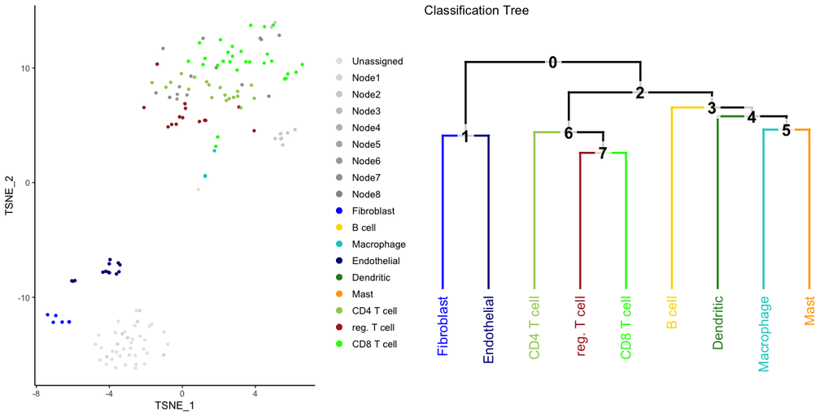

```r
PlotCHETAH(input = input_mel)
```

Please note that each type “NodeX” corresponds to the node with number X and that the type “Unassigned” corresponds to the node 0

Conversely, to color the **intermediate types**:

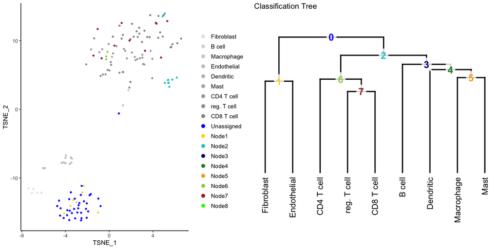

```r
PlotCHETAH(input = input_mel, interm = TRUE)
```

If you would like to use the classification, and thus the colors, in another package (e.g. Seurat<sup>2</sup>), you can extract the colors using:

```r
colors <- PlotCHETAH(input = input_mel, return_col = TRUE)
```

## 5.3 `CHETAHshiny`

The classification of CHETAH and other outputs like profile and confidence scores can be visualized in a shiny application that allows for easy and interactive analysis of the classification.

Here you can view:

- the confidence of all assignments
- the classification in an interactive window
- the genes used by CHETAH, an it’s expression in the input data
- a lot more

The following command will open the shiny application as in an R window. The page can also be opened in your default web-browser by clicking “Open in Browser” at the very top.

```r
CHETAHshiny(input = input_mel)
```

# 6 Changing classification

## 6.1 Confidence score

CHETAH calculates a confidence score for each assignment of an input cell to one of the branches of a node.  
The confidence score:

- has a value between 0 and 2
- will normally lie between 0 and 1
- 0 represents no confidence for an assignment, 1 high confidence.

**The default confidence threshold of CHETAH is 0.1.**  
This means that whenever a cell is assigned to a branch and the confidence of that assignment is lower than 0.1, the classification will stop in that node.

**The confidence threshold can be adjusted in order to classify more or fewer cells to a final type:**

- Using a confidence threshold of 0 will classify all input cells to a final type. Be aware that this classification can be noisy and can contain incorrect classifications.
- Using a threshold of 0.2, 0.3, 0.4, etc, will classify a decreasing number of cells to a final type, with the remaining cells having a increasingly high confidence throughout all nodes in the tree.

For example, to only classify cells with very high confidence:

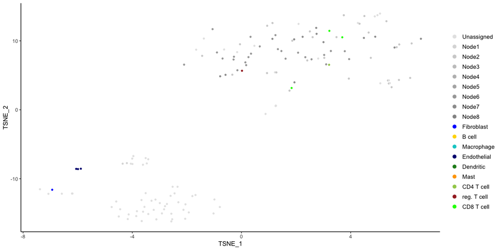

```r
input_mel <- Classify(input = input_mel, 0.8)
PlotCHETAH(input = input_mel, tree = FALSE)
```

Conversely, to classify all cells:

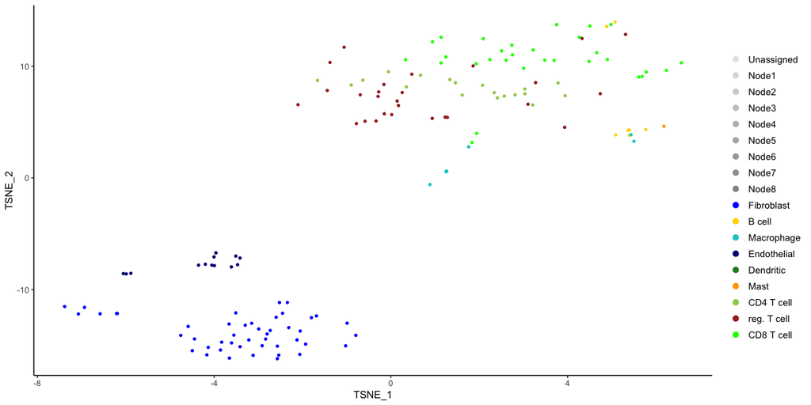

```r
input_mel <- Classify(input_mel, 0)
PlotCHETAH(input = input_mel, tree = FALSE)
```

## 6.2 Renaming types

For renaming types in the tree, CHETAH comes with the `RenameBelowNode` function. This can be interesting when you are more interested in the general types, type in the different **intermediate** and **final types**.

For the example data, let’s say that we are not interested in all the different subtypes of T-cells (under Node6 and Node7), we can name all these cells “T cells” by running:

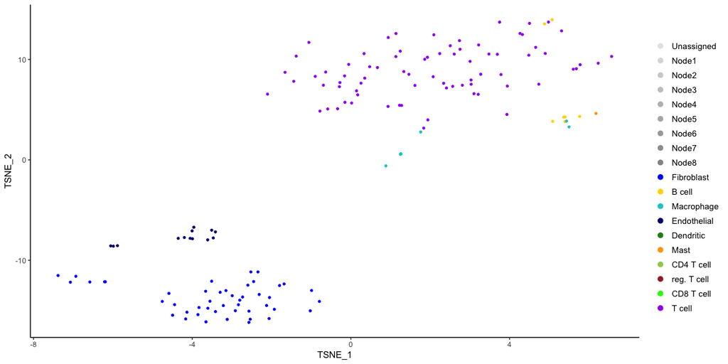

```r
input_mel <- RenameBelowNode(input_mel, whichnode = 6, replacement = "T cell")
PlotCHETAH(input = input_mel, tree = FALSE)
```

To reset the classification to its default, just run `Classify` again:

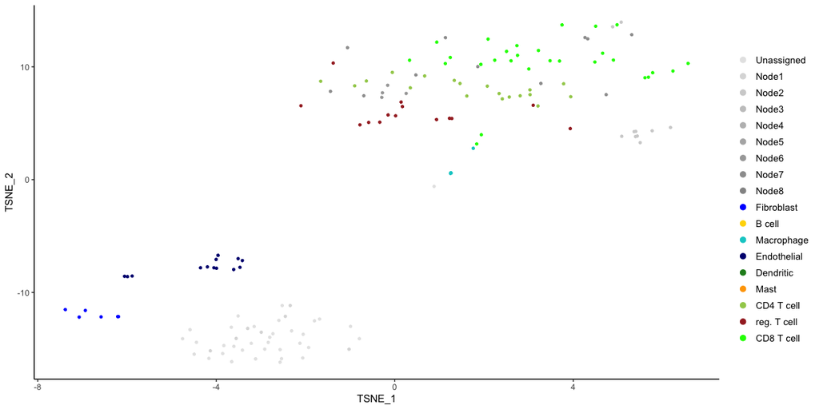

```r
input_mel <- Classify(input_mel) ## the same as Classify(input_mel, 0.1)
PlotCHETAH(input = input_mel, tree = FALSE)
```

# 7 Creating a reference

## 7.1 Step 0: Obtain a reference.

- Download or use one of your own scRNA-seq datasets, for which cell type labels are available.
  - A tumor micro-environment reference dataset containing all major cell types for tumor data can be downloaded [here](https://figshare.com/s/aaf026376912366f81b6)
- Make a `SingleCellExperiment` object, as explained above

## 7.2 Step 1: good reference characteristics

CHETAH can use any scRNA-seq reference, but the used reference greatly influences the classification.  
The following general rules apply on choosing and creating a reference:

- Better results can be achieved by using a reference and an input dataset that are from the same biological type, or at least consist of cells that are in the same cell state. E.g. for an input dataset of PBMCs, a bone marrow reference dataset could be used, but as these cells are more naive or precursor cells, this might negatively influence the classification. In this case, another PBMC dataset would work optimally.
- The annotation of the reference directly influences the classification. The more accurate the cell type labels, the better the classification. Also, discard any cells that are doublets, contaminations, etc.
- The sparser the reference data, the more reference cells are needed to create a reliable reference. For high coverage Smart-Seq2<sup>3</sup> data, as little as 10-20 cells are needed per cell type. For sparser 10X Genomics data, 100+ cells normally gives optimal results.

To reduce computation time with very big references, first try to subsample each cell type to 100-200 cells. CHETAH should have very similar performance to using all cells. For a `SingleCellExperiment` “ref” with cell type metadata “celltypes”, this could be done by:

```r
cell_selection <- unlist(lapply(unique(ref$celltypes), function(type) {
    type_cells <- which(ref$celltypes == type)
    if (length(type_cells) > 200) {
        type_cells[sample(length(type_cells), 200)]
    } else type_cells
}))
ref_new <- ref[ ,cell_selection]
```

## 7.3 Step 1: normalization

CHETAH does not require normalized input data, but **the reference data has to be normalized beforehand**. The reference data that is used in this vignette is already normalized. **Only for sake of the example**, we use this dataset anyway to perform nomalization:

```r
assay(headneck_ref, "counts") <- apply(assay(headneck_ref, "counts"), 2, function(column) log2((column/sum(column) * 100000) + 1))
```

## 7.4 Step 2: discaring of house-keeping genes

Certainly with reference with relatively high drop-out rates, CHETAH can be influenced by highly expressed, and thus highly variable, genes. In our experience, mainly ribosomal protein genes can cause such an effect. We therefore delete these genes, using the “ribosomal” list from [here](https://figshare.com/s/aaf026376912366f81b6)

```r
ribo <- read.table("~/ribosomal.txt", header = FALSE, sep = '\t')
headneck_ref <- headneck_ref[!rownames(headneck_ref) %in% ribo[,1], ]
```

## 7.5 Step 3: Reference QC

The performance of CHETAH is heavily dependent on the quality of the reference.  
The quality of the reference is affected by:

1. the quality of the scRNA-seq data
2. the accuracy of the cell type labels

To see how well CHETAH can distinguish between the cell types in a reference,  
`CorrelateReference` and more importantly `ClassifyReference` can be run.

### 7.5.1 CorrelateReference

`CorrelateReference` is a function that, for every combination of two cell types, finds the genes with the highest fold-change between the two and uses these to correlate them to each other. If the reference is good, all types will correlate poorly or even better, will anti-correlate.

```r
CorrelateReference(ref_cells = headneck_ref)
```

```
#> Running... in case of 1000s of cells, this may take a couple of minutes
```

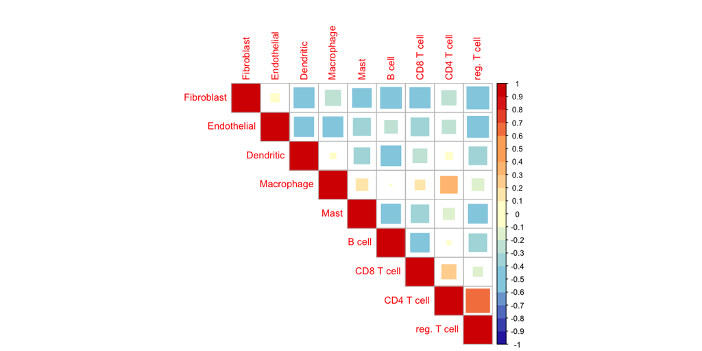

In this case, most cell types will be distinguishable: many types don’t correlate, or anti-correlate. However, some types are quite similar. Regulatory and CD4 T cells, or CD4 and CD8 T cells, might be hard to distinguish in the input data.

### 7.5.2 ClassifyReference

Another check to see whether CHETAH can distinguish between the cell types in the reference is `ClassifyReference`. This function uses the reference to classify the reference itself. If CHETAH works well with the reference, there should be almost no mix-ups in the classification, i.e. all cells of type A should be classified to type A.

```r
ClassifyReference(ref_cells = headneck_ref)
```

```
#> Preparing data....
#> Running analysis...
```

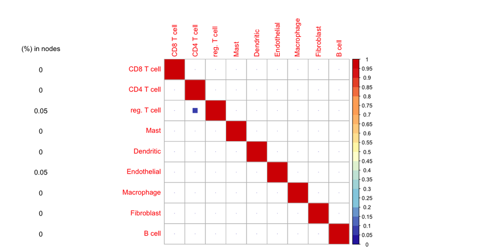

In this reference, there is never more than 10% mix-up between two cell types. In addition, a low percentage of cells is classified as an intermediate type. Most mix-ups occur between subtypes of T cells. In this case the user should be aware that these cell type labels have the highest chance to interchange.

# 8 Optimizing the classification

<sup>1</sup> Van Der Maaten and Hinton (2008). Visualizing high-dimensional data using t-sne. *J Mach Learn Res*. 9: 2579-2605. doi: 10.1007/s10479-011-0841-3.  
<sup>2</sup> Satija et al. (2015) Spatial reconstruction of single-cell gene expression data. *Nat Biotechnol*. 33(5):495-502. May 2015. doi: 10.1038/nbt.3192. More information at: https://satijalab.org/seurat/  
<sup>3</sup> Picelli et al. (2013) Smart-seq2 for sensitive full-length transcriptome profiling in single cells. *Nat Methods*. 10(11): 1096-1100. doi: 10.1038/nmeth.2639.